# Practical Machine Learning - Prediction Assignment

# Background

Using devices such as Jawbone Up, Nike FuelBand, and Fitbit it is now possible to collect a large amount of data about personal activity relatively inexpensively. These type of devices are part of the quantified self movement – a group of enthusiasts who take measurements about themselves regularly to improve their health, to find patterns in their behavior, or because they are tech geeks. One thing that people regularly do is quantify how much of a particular activity they do, but they rarely quantify how well they do it. In this project, your goal will be to use data from accelerometers on the belt, forearm, arm, and dumbell of 6 participants. They were asked to perform barbell lifts correctly and incorrectly in 5 different ways. More information is available from the website here: http://groupware.les.inf.puc-rio.br/har (see the section on the Weight Lifting Exercise Dataset).

# Data

The training data for this project are available here: https://d396qusza40orc.cloudfront.net/predmachlearn/pml-training.csv

The test data are available here: https://d396qusza40orc.cloudfront.net/predmachlearn/pml-testing.csv

The data for this project come from this source: http://groupware.les.inf.puc-rio.br/har. If you use the document you create for this class for any purpose please cite them as they have been very generous in allowing their data to be used for this kind of assignment.

# Goal of project

The goal of your project is to predict the manner in which they did the exercise. This is the “classe” variable in the training set. You may use any of the other variables to predict with. You should create a report describing how you built your model, how you used cross validation, what you think the expected out of sample error is, and why you made the choices you did. You will also use your prediction model to predict 20 different test cases.

```r
#Multithread this
doMC::registerDoMC(cores=4)
download.file("https://d396qusza40orc.cloudfront.net/predmachlearn/pml-training.csv", "~/workspace/Practical Machine Learning/pml-training.csv")
download.file("https://d396qusza40orc.cloudfront.net/predmachlearn/pml-testing.csv", "~/workspace/Practical Machine Learning/pml-testing.csv")
training <- read.csv("~/workspace/Practical Machine Learning/pml-training.csv", na.strings = c("NA","#DIV/0", ""))
testing <- read.csv("~/workspace/Practical Machine Learning/pml-testing.csv", na.strings=c("NA", "#DIV/0",""))
##Remove unnecessary variables.
training <- training[,-c(1:7)]
zeroVars <- nearZeroVar(training, saveMetrics=T)
training <- training[,!zeroVars$nzv]

testing<- testing[,-c(1:7)]
testing<- testing[,!zeroVars$nzv]

##Lets see how many NA values we have
naPercent <- sapply(training, function(y) sum(length(which(is.na(y))))/nrow(training))
training <- training[,naPercent < 0.9]
testing <- testing[,naPercent < 0.9]
training$classe <- as.factor(training$classe)

inTrain <- createDataPartition(training$classe, p=0.6, list=FALSE)
myTraining <- training[inTrain, ]
myTesting <- training[-inTrain, ]
```

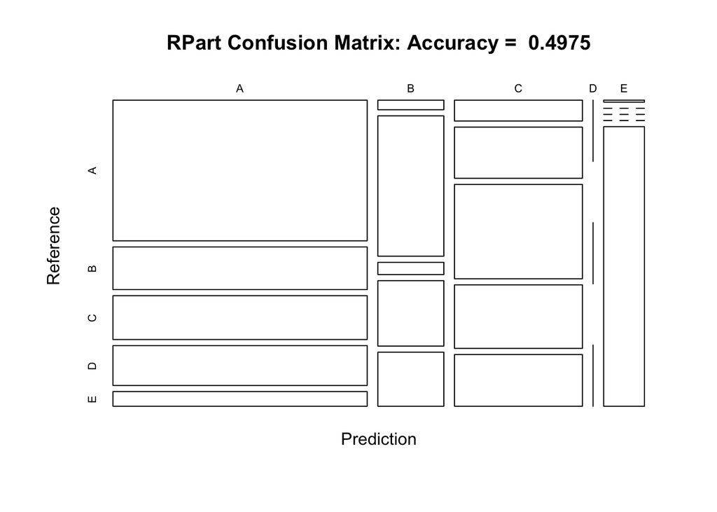

```r
set.seed(5)
#Try with rpart
rpartModFit <- train(classe~., method="rpart", data=myTraining)
rpartPred <- predict(rpartModFit, myTraining)
rpartCm <- confusionMatrix(rpartPred, myTraining$classe)
plot(rpartCm$table, col=rpartCm$byClass, main=paste("RPart Confusion Matrix: Accuracy = ", round(rpartCm$overall['Accuracy'], 4)))
```

The Rpart prediction model did not fit well into our data, and it looks like theres a high sample error rate (51%). Let’s try fitting another model on the data to see how the predicitons look.

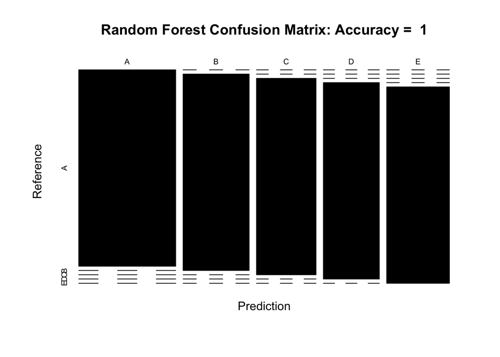

```r
set.seed(5)
#Try with randomForest
rfModFit <- randomForest(classe~., data=myTraining)
rfPred <- predict(rfModFit, myTraining)
rfCm <- confusionMatrix(rfPred, myTraining$classe)
plot(rfCm$table, col=rfCm$byClass, main=paste("Random Forest Confusion Matrix: Accuracy = ", round(rfCm$overall['Accuracy'], 4)))
```

Using random forests for the method seems to lower our sample error down dramatically. Our sample error rate is 0, but thats likely because of overfitting. Let’s see if generalized boosted regression will also be a good model for our data.

```r
set.seed(5)
#Try with gbm
control <- trainControl(method="repeatedcv", number=4, repeats=1)
gbmModFit <- train(classe~., method="gbm", data=myTraining, trControl=control)
gbmPred <- predict(gbmModFit, myTraining)
(gbmCm <- confusionMatrix(gbmPred, myTraining$classe))
```

```
## Confusion Matrix and Statistics
##
##           Reference
## Prediction    A    B    C    D    E
##          A 3313   48    0    1    1
##          B   25 2196   41    4   16
##          C    9   35 1992   46    8
##          D    1    0   18 1873   23
##          E    0    0    3    6 2117
##
## Overall Statistics
##
##                Accuracy : 0.9758
##                  95% CI : (0.9729, 0.9785)
##     No Information Rate : 0.2843
##     P-Value [Acc > NIR] : < 2.2e-16
##
##                   Kappa : 0.9694
##  Mcnemar's Test P-Value : 1.381e-09
##
## Statistics by Class:
##
##                      Class: A Class: B Class: C Class: D Class: E
## Sensitivity            0.9895   0.9636   0.9698   0.9705   0.9778
## Specificity            0.9941   0.9909   0.9899   0.9957   0.9991
## Pos Pred Value         0.9851   0.9623   0.9531   0.9781   0.9958
## Neg Pred Value         0.9958   0.9913   0.9936   0.9942   0.9950
## Prevalence             0.2843   0.1935   0.1744   0.1639   0.1838
## Detection Rate         0.2813   0.1865   0.1692   0.1591   0.1798
## Detection Prevalence   0.2856   0.1938   0.1775   0.1626   0.1805
## Balanced Accuracy      0.9918   0.9773   0.9799   0.9831   0.9884
```

[figure not shown]

```r
plot(gbmCm$table, col=gbmCm$byClass, main=paste("RPart Confusion Matrix: Accuracy = ", round(gbmCm$overall['Accuracy'], 4)))
```

```r
rfPredTest<- predict(rfModFit, myTesting)
confusionMatrix(rfPredTest, myTesting$classe)
```

```
## Confusion Matrix and Statistics
##
##           Reference
## Prediction    A    B    C    D    E
##          A 2230   11    0    0    0
##          B    2 1502    6    0    0
##          C    0    5 1356   22    3
##          D    0    0    6 1264    0
##          E    0    0    0    0 1439
##
## Overall Statistics
##
##                Accuracy : 0.993
##                  95% CI : (0.9909, 0.9947)
##     No Information Rate : 0.2845
##     P-Value [Acc > NIR] : < 2.2e-16
##
##                   Kappa : 0.9911
##  Mcnemar's Test P-Value : NA
##
## Statistics by Class:
##
##                      Class: A Class: B Class: C Class: D Class: E
## Sensitivity            0.9991   0.9895   0.9912   0.9829   0.9979
## Specificity            0.9980   0.9987   0.9954   0.9991   1.0000
## Pos Pred Value         0.9951   0.9947   0.9784   0.9953   1.0000
## Neg Pred Value         0.9996   0.9975   0.9981   0.9967   0.9995
## Prevalence             0.2845   0.1935   0.1744   0.1639   0.1838
## Detection Rate         0.2842   0.1914   0.1728   0.1611   0.1834
## Detection Prevalence   0.2856   0.1925   0.1767   0.1619   0.1834
## Balanced Accuracy      0.9986   0.9941   0.9933   0.9910   0.9990
```

Even after cross validation, we still see a very low sample error. Lets predict the 20 test variables.

```r
rfPredTest<- predict(rfModFit, testing)
rfPredTest
```

```
##  1  2  3  4  5  6  7  8  9 10 11 12 13 14 15 16 17 18 19 20
##  B  A  B  A  A  E  D  B  A  A  B  C  B  A  E  E  A  B  B  B
## Levels: A B C D E
```